# Part II - Ford GoBike System Presentation

## by Tersoo Adorowa

## Investigation Overview

> In this analysis, I investigate users' features and relate them to trips, which can be used to predict the demand for bikes. The main focus was on the members' age, gender, and type, but the duration of trips, and if bikes were shared for all trips also were explored variables.

## Dataset Overview

> This data set includes information about individual rides made in a bike-sharing system covering the greater San Francisco Bay area.

## Count of Member Gender

> There are more men than women by landslide margin. There is also the 'other' which can be overlooked.

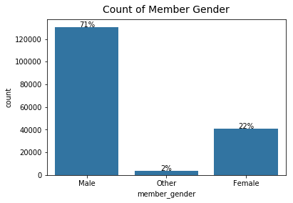

## Member Ages Vs. Member Genders

```
Text(0.5,1.015,'Member age vs. member gender')
```

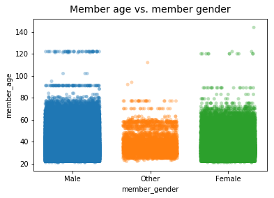

## Analysis of Users

> The graph 1 shows that there are more men than other genders. The graph 2 shows that men are majority in all age groups. In the graphs 3 and 4, men are mojority of the clients. The majority of clients are subscriber.

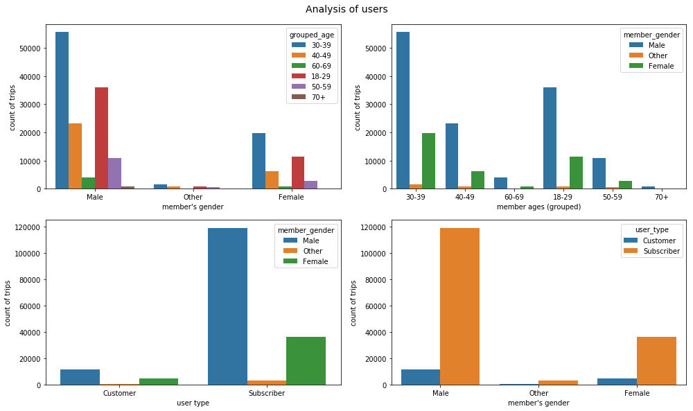